# Practical Machine Learning - Project

Roberto Gonzalo Rodriguez

23 de agosto de 2015

## Getting the data

The dataset was obtained from http://groupware.les.inf.puc-rio.br/har and was acquired from accelerometers on the belt, forearm, arm and dumbell of six participants.

```r
# Read Csv File
pml <- read.csv("pml-training.csv", na.strings = c("NA","#DIV/0!"))

# Dimension
dim(pml)
```

```
## [1] 19622   160
```

## Exploratory Analysis

At the first step, we performed an exploratory analysis in order to design the study. The data set contains 160 variables recorded for 19622 measures. A sample of data is shown below.

```r
str(pml, list.len=10)
```

```
## 'data.frame':    19622 obs. of  160 variables:
##  $ X                       : int  1 2 3 4 5 6 7 8 9 10 ...
##  $ user_name               : Factor w/ 6 levels "adelmo","carlitos",..: 2 2 2 2 2 2 2 2 2 2 ...
##  $ raw_timestamp_part_1    : int  1323084231 1323084231 1323084231 1323084232 1323084232 1323084232 1323084232 1323084232 1323084232 1323084232 ...
##  $ raw_timestamp_part_2    : int  788290 808298 820366 120339 196328 304277 368296 440390 484323 484434 ...
##  $ cvtd_timestamp          : Factor w/ 20 levels "02/12/2011 13:32",..: 9 9 9 9 9 9 9 9 9 9 ...
##  $ new_window              : Factor w/ 2 levels "no","yes": 1 1 1 1 1 1 1 1 1 1 ...
##  $ num_window              : int  11 11 11 12 12 12 12 12 12 12 ...
##  $ roll_belt               : num  1.41 1.41 1.42 1.48 1.48 1.45 1.42 1.42 1.43 1.45 ...
##  $ pitch_belt              : num  8.07 8.07 8.07 8.05 8.07 8.06 8.09 8.13 8.16 8.17 ...
##  $ yaw_belt                : num  -94.4 -94.4 -94.4 -94.4 -94.4 -94.4 -94.4 -94.4 -94.4 -94.4 ...
##   [list output truncated]
```

| X | user_name | raw_timestamp_part_1 | raw_timestamp_part_2 | cvtd_timestamp | new_window | num_window | roll_belt | pitch_belt | yaw_belt | total_accel_belt | kurtosis_roll_belt | kurtosis_picth_belt | kurtosis_yaw_belt | skewness_roll_belt | skewness_roll_belt.1 | skewness_yaw_belt | max_roll_belt | max_picth_belt | max_yaw_belt | min_roll_belt | min_pitch_belt | min_yaw_belt | amplitude_roll_belt | amplitude_pitch_belt | amplitude_yaw_belt | var_total_accel_belt | avg_roll_belt | stddev_roll_belt | var_roll_belt | … |
| --- | --- | --- | --- | --- | --- | --- | --- | --- | --- | --- | --- | --- | --- | --- | --- | --- | --- | --- | --- | --- | --- | --- | --- | --- | --- | --- | --- | --- | --- | --- |
| 1 | carlitos | 1323084231 | 788290 | 05/12/2011 11:23 | no | 11 | 1.41 | 8.07 | -94.4 | 3 | NA | NA | NA | NA | NA | NA | NA | NA | NA | NA | NA | NA | NA | NA | NA | NA | NA | NA | NA | … |
| 2 | carlitos | 1323084231 | 808298 | 05/12/2011 11:23 | no | 11 | 1.41 | 8.07 | -94.4 | 3 | NA | NA | NA | NA | NA | NA | NA | NA | NA | NA | NA | NA | NA | NA | NA | NA | NA | NA | NA | … |
| 3 | carlitos | 1323084231 | 820366 | 05/12/2011 11:23 | no | 11 | 1.42 | 8.07 | -94.4 | 3 | NA | NA | NA | NA | NA | NA | NA | NA | NA | NA | NA | NA | NA | NA | NA | NA | NA | NA | NA | … |
| 4 | carlitos | 1323084232 | 120339 | 05/12/2011 11:23 | no | 12 | 1.48 | 8.05 | -94.4 | 3 | NA | NA | NA | NA | NA | NA | NA | NA | NA | NA | NA | NA | NA | NA | NA | NA | NA | NA | NA | … |
| 5 | carlitos | 1323084232 | 196328 | 05/12/2011 11:23 | no | 12 | 1.48 | 8.07 | -94.4 | 3 | NA | NA | NA | NA | NA | NA | NA | NA | NA | NA | NA | NA | NA | NA | NA | NA | NA | NA | NA | … |
| 6 | carlitos | 1323084232 | 304277 | 05/12/2011 11:23 | no | 12 | 1.45 | 8.06 | -94.4 | 3 | NA | NA | NA | NA | NA | NA | NA | NA | NA | NA | NA | NA | NA | NA | NA | NA | NA | NA | NA | … |

## Preparing the predictors

Before training the model, we need to clean up the data, impute missing values if needed, and select the predictors that better describe the outcome. Browsing the data, we can conclude that columns like record number and time stamp columns should be avoided.

```r
pml <- select(pml, -X, -raw_timestamp_part_1, -raw_timestamp_part_2, -cvtd_timestamp)
```

We could detect that there are many columns that contains null values for many records. We decided not to impute any missing data in the first model fitting, so we excluded all parameters that have at least one NA value.

```r
# Exclude columns with NAs
pml <- pml[ , apply(pml, 2, function(x) !any(is.na(x)))]
```

There could be predictors that are constants or nearly constant values. To detect and exclude those variables, we use the `nearZeroVar` function of the `caret` package.

```r
# Near zero predictors
nearZeroValues <- nearZeroVar(pml, saveMetrics= TRUE)
# Delete near zero predictors
colsToDelete <- row.names(nearZeroValues[nearZeroValues$nzv==TRUE,])
pml <- pml[, -which(names(pml) %in% colsToDelete)]
```

Because it is possible that highly correlated predictors exist, we use the `findCorrelation` function of the `caret` package to detect and exclude those variables

```r
# Identifying Correlated Predictors

# Get Name of the numeric columns
columnTypes <- melt(sapply(pml, is.numeric))
numColumns <- row.names(columnTypes)[columnTypes$value == TRUE]
descrCor <- cor(pml[, which( names(pml) %in% numColumns)])

# Find highly correlated columns (corr > 0.90)
correlatedColumns <- findCorrelation(descrCor)

# Delete Highly correlated columns
pml <- pml[, -which(names(pml) %in% numColumns[correlatedColumns])]
```

Now that we have exclude unnecessary colums for our first model fitting, our data set consists now of 48 columns which will allow us to create a better model in less time.

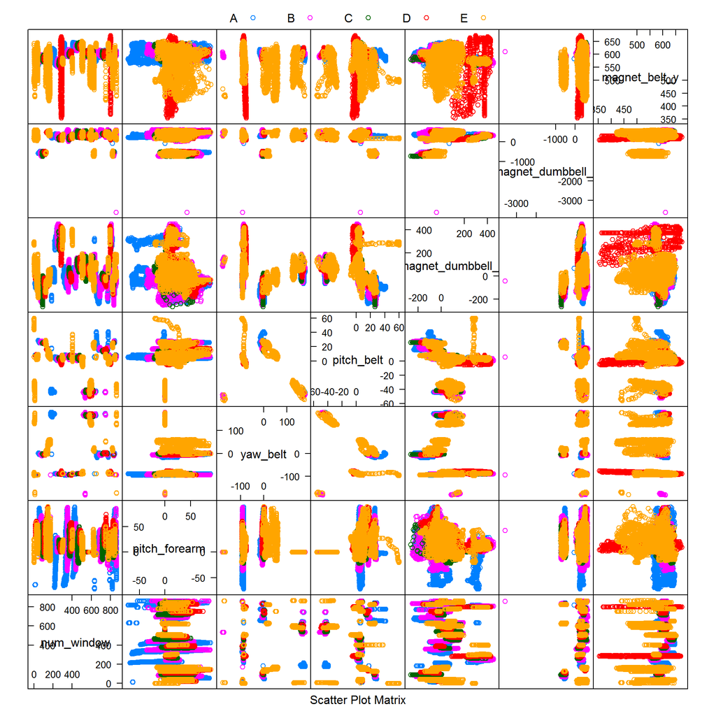

## Partition Training and Testing

The last step before training the model is splitting the data set into a training and testing set that will be used at the end to evaluate the out of sample error. We used the `createDataPartition` function of the `caret` package for this task.

```r
# Set seed for reproducibility
set.seed(1)
# Training set 60% / Test Set 40% of the data
trainIndex <- createDataPartition(pml$classe, p = 0.6, list = FALSE)
train <- pml[trainIndex,]
test <- pml[-trainIndex,]
```

## Fitting the Model

```r
# 5-fold Cross validation, repeated 3 times
fitControl <- trainControl(
    method = "repeatedcv",
    number = 5, repeats = 3)

# Use parallel processing
registerDoParallel(cores=4)

# Fit the random forest
fit.rf <- train(classe ~ ., data = train, trControl=fitControl,method = "rf")
fit.rf
```

```
## Random Forest
##
## 11776 samples
##    47 predictor
##     5 classes: 'A', 'B', 'C', 'D', 'E'
##
## No pre-processing
## Resampling: Cross-Validated (5 fold, repeated 3 times)
##
## Summary of sample sizes: 9422, 9421, 9421, 9420, 9420, 9421, ...
##
## Resampling results across tuning parameters:
##
##   mtry  Accuracy   Kappa      Accuracy SD  Kappa SD
##    2    0.9903191  0.9877529  0.001715962  0.002171477
##   26    0.9960089  0.9949514  0.001848968  0.002339260
##   51    0.9912537  0.9889369  0.002624928  0.003320224
##
## Accuracy was used to select the optimal model using  the largest value.
## The final value used for the model was mtry = 26.
```

```r
# Save model for further use
save(file="fit_rf", fit.rf)
```

The process took about 10 minutes in an Intel i5 (4 cores) 2.66Ghz 8GB RAM. We used parallel process and the optimized Revolution Analytics R 3.2.1 (64 bits) version.

## Accuracy

The created model seems to have an astonishing accuracy of 1 (100%) for the training data. This can be shown below where we used the `confusionMatrix` function to measure the in sample error.

```r
# Confussion Matrix for the training data set
confusionMatrix(predict(fit.rf,newdata = train), train$classe)
```

```
## Confusion Matrix and Statistics
##
##           Reference
## Prediction    A    B    C    D    E
##          A 3348    0    0    0    0
##          B    0 2279    0    0    0
##          C    0    0 2054    0    0
##          D    0    0    0 1930    0
##          E    0    0    0    0 2165
##
## Overall Statistics
##
##                Accuracy : 1
##                  95% CI : (0.9997, 1)
##     No Information Rate : 0.2843
##     P-Value [Acc > NIR] : < 2.2e-16
##
##                   Kappa : 1
##  Mcnemar's Test P-Value : NA
##
## Statistics by Class:
##
##                      Class: A Class: B Class: C Class: D Class: E
## Sensitivity            1.0000   1.0000   1.0000   1.0000   1.0000
## Specificity            1.0000   1.0000   1.0000   1.0000   1.0000
## Pos Pred Value         1.0000   1.0000   1.0000   1.0000   1.0000
## Neg Pred Value         1.0000   1.0000   1.0000   1.0000   1.0000
## Prevalence             0.2843   0.1935   0.1744   0.1639   0.1838
## Detection Rate         0.2843   0.1935   0.1744   0.1639   0.1838
## Detection Prevalence   0.2843   0.1935   0.1744   0.1639   0.1838
## Balanced Accuracy      1.0000   1.0000   1.0000   1.0000   1.0000
```

This perfect result may well be due to overfitting. That is why we partitioned the data and have a testing data set that was not used in training. We expect the accurary to be lower than the shown in the confusion matrix above. Depending on how smaller it is we will conclude about the validity of our model.

```r
# Prediction - Testing set
test.pred <- predict(fit.rf, newdata = test)

# Confussion Matrix for the testing data set
cm <- confusionMatrix(test.pred, test$classe)
cm
```

```
## Confusion Matrix and Statistics
##
##           Reference
## Prediction    A    B    C    D    E
##          A 2232    1    0    0    0
##          B    0 1514    2    0    0
##          C    0    2 1363    3    0
##          D    0    1    3 1283    4
##          E    0    0    0    0 1438
##
## Overall Statistics
##
##                Accuracy : 0.998
##                  95% CI : (0.9967, 0.9988)
##     No Information Rate : 0.2845
##     P-Value [Acc > NIR] : < 2.2e-16
##
##                   Kappa : 0.9974
##  Mcnemar's Test P-Value : NA
##
## Statistics by Class:
##
##                      Class: A Class: B Class: C Class: D Class: E
## Sensitivity            1.0000   0.9974   0.9963   0.9977   0.9972
## Specificity            0.9998   0.9997   0.9992   0.9988   1.0000
## Pos Pred Value         0.9996   0.9987   0.9963   0.9938   1.0000
## Neg Pred Value         1.0000   0.9994   0.9992   0.9995   0.9994
## Prevalence             0.2845   0.1935   0.1744   0.1639   0.1838
## Detection Rate         0.2845   0.1930   0.1737   0.1635   0.1833
## Detection Prevalence   0.2846   0.1932   0.1744   0.1645   0.1833
## Balanced Accuracy      0.9999   0.9985   0.9978   0.9982   0.9986
```

As we expected, the accuracy **0.998** is smaller but still high and the missclasified records just a few. The conclusion then is that the fitted model was not overfitted but the chossen variables and parameters calculated were enough to predict with high accuracy the type of excercise the individuals performed.

## Important Variables

Given the model fitted we can get the most important variables that explain the outcome. See below,

```r
# Random Forest Variable Importance
varImp(fit.rf)
```

```
## rf variable importance
##
##   only 20 most important variables shown (out of 51)
##
##                      Overall
## num_window           100.000
## pitch_forearm         40.817
## yaw_belt              40.134
## pitch_belt            32.909
## magnet_dumbbell_z     30.264
## magnet_dumbbell_y     25.506
## magnet_belt_y         23.165
## roll_forearm          19.562
## roll_dumbbell         12.530
## accel_dumbbell_y      12.307
## magnet_dumbbell_x     11.784
## magnet_belt_z         10.537
## accel_forearm_x       10.504
## total_accel_belt       9.933
## gyros_belt_z           9.748
## total_accel_dumbbell   8.519
## accel_dumbbell_z       8.511
## magnet_belt_x          7.894
## accel_forearm_z        7.243
## roll_arm               6.535
```

## Conclusion

Using random forest and repeated (3 times) cross validation (K=5) with a reduced set of variables we were able to fit a model with excelent accuracy. Even when this model predictive capacities are difficult to overcome, other models could be fitted in order to make it simpler and faster and at the same time preserve the high level of accuracy.